# Assignment 0

Kaylena Mann  
ADEC7430  
09/01/25

## 1. Screenshot showing my conda environments

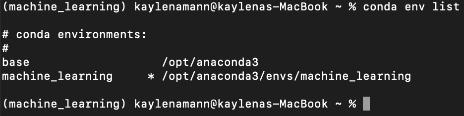

## 2. What a conda environment is and why it is useful

A **conda environment** is a workspace for installing specific packages, libraries, etc., for a project. This environment can be shared and is self-contained, meaning that whatever one does in that environment will not affect the system as a whole or other environments.

This is useful by aiding in organization within said project, assuring that it is reproducible between people and time points! This makes collaboration easier while ensuring that no projects interfere with each other or break code due to updating packages, libraries, etc.

## 3. A summary of key takeaways from the two python notebooks

### 3.1 Notebook 1 Summary

Python as a whole is relatively easy to read and learn, with few lines of code to quickly identify potential errors, while still being powerful enough for big data. It uses **0-based indexing**, which makes some operations and looping easier.

You can easily assign data to a variable by using the “=” operator, which can be manipulated with other operators like “*”, (multiplication), “+=” (increment), “-=”(decrement), and “**” (exponents). In addition to these simple operators, one can also utilize inequalities “!=”, do comparisons “<=”, or even negate with “NOT” before a line of code.

```python
#example for assigning variables and manipulating said variable
x = 10; x += 5
x
```

```
15
```

In Python, numbers can be **floats** (decimals) or **integers** (whole numbers). You can see the type of number by inputting “type()”, and convert a variable to an integer or a float by assigning x = int() or x = float(). Booleans can also be used, with logical operations, to specify “true” or “false”.

```python
#example for seeing what type of variable x is and a Boolean
print(type(x))

print(x==10)
```

```
<class 'int'>
False
```

```python
# Example string defining
t = "I am excited to start learning Python!"
len(t)
```

```
38
```

Container types are **lists**, **tuples**, **sets**, and **dictionaries**. Lists can contain any type of data, such as integers, floats, strings, mix and match, etc. Just like strings, these are iterable, meaning we can access indexes through code like “int_list[2]”. Lists can be nested “x = [[1,2,3],[4,5,6]]”, or added to with the "append" code. These are mutable, meaning you can assign a new value to a certain index.

Tuples are similar in that they are iterable, but they are not mutable. Sets are also similar to lists, but cannot contain duplicate elements. Dictionaries (discussed in the second notebook) are another type of data structure that maps values to keys. These are mutable, but unlike lists and tuples, are unordered. To access a part of a dictionary, the key must be used instead of the index, like "my_dict[a]".

One can bring items together by using the “zip” code. If one has two lists, they can zip them together to create tuples based on their location in the lists!

```python
x = (1, 7, 10, 12)
y = ("failed", "passed", "passed", "passed")

variable_list = list(zip(x, y))
variable_list
```

```
[(1, 'failed'), (7, 'passed'), (10, 'passed'), (12, 'passed')]
```

### 3.2 Notebook 2 Summary

**List comprehensions** are a more concise way to make lists and loop over container types. For example, if one makes a list, they can easily just use one line of code instead of doing an entire "FOR" loop.

```python
# Example of a list comprehension
result = [n + 6 if n < 5 else 2 for n in x]
result
```

```
[7, 2, 2, 2]
```

**Logical operators**, as discussed in part 1, can test for a condition and return TRUE or FALSE. One can also use ALL(will return true if all conditions are met) or ANY (will return true if at least one condition is met) to get more specific with these tests.

```python
# Example condition and use of "all"
cond = [i < 15 for i in x]
all(cond)
```

```
True
```

Another essential aspect of Python is understanding **indentation**, which is meaningful when doing loops (such as when using if, elif, and else).

Additionally, one can use “TRY” and “EXCEPT” to do some error-checking.

```python
#Example FOR loop indentation

for item in x:
    if item > 10:
        print("{Value} is too big")
    elif item == 10:
        print("{Value} is just right")
    else:
        print("{Value} is too small")
```

```
{Value} is too small
{Value} is too small
{Value} is just right
{Value} is too big
```

Code with the “%” or “%%” symbol before are known as **magic**. For example, one can save their functions to a specific file with the ".py" extension to reuse, especially if they know they will use that code a lot. E.g., “%%file some_module.py”. Additionally, one can lookup what is imported with “%whos” and get more information by using “help()” if they forget.

```python
# example of a magic command
%whos
```

[output not shown]

**Functions** can have positional or keyword arguments, with positional arguments always first. These behave like data objects, with the ability to be stored, assigned to other functions, etc. If one wants to use a function just one-time instead of saving it for future use, they can use “LAMBDAS”.

```python
#example of using the Lambda function
multiply_each = lambda x: x**x
multiply_each(6)
```

```
46656
```

Finally, when printing or iterating through a lot of data (as in big data and deeplearning) **generators** can be helpful. With generators, the values are generated as they are requested instead of stored all at once, which can take time and power.

Also, **decorators** are a function that modifies a function and returns a function! It seemed confusing at first, but it is often helpful to wrap up a function in something else, to do something before and after another function, while still keeping the original function intact.

```python
#example decorator to turn the items from earlier into strings

def make_string(func):
    def wrapper():
        items = func()
        return [f"Item: {str(item)}" for item in items]
    return wrapper

@make_string
def multiplication():
    return [1, 3, 10, 12]

print(multiplication())
```

```
['Item: 1', 'Item: 3', 'Item: 10', 'Item: 12']
```